# 02. ITS2 basic analysis

Cutadapt paired-end 기반 True sample 및 control profile

2026-10-15

# 1 1. Dataset

## 1.1 분석 목표 및 입력

- 분석 목표: True skin sample과 negative control 간 alpha diversity, beta diversity 및 taxonomic composition 차이의 기초 확인
- phyloseq 입력: QIIME 2 taxa barplot의 non-rarefied species count와 sample metadata를 결합한 `phy` object
- diversity 입력: non-rarefied phyloseq count를 사용함. alpha diversity는 raw count, Bray–Curtis는 relative abundance, Jaccard는 presence/absence로 계산함
- rarefaction: sample filtering 또는 분석 포함 기준으로 사용하지 않고 sequencing depth에 따른 observed richness 추이만 제시함
- 추가 filtering: Kingdom이 Fungi인 taxon을 유지한 뒤 zero-depth sample 및 zero-sum taxon만 제거함. abundance threshold와 decontam은 적용하지 않음
- 연구 구조: 2개 skin subject와 3개 control source에서 PCR cycle 조건을 반복 측정한 탐색 자료임
- Skin sample은 대상자와 좌/우를 포함한 해부학적 site를 유지하며, 동일 biological unit에서 PCR 조건별 library가 반복된 구조로 분석함

## 1.2 Phyloseq preprocessing 및 taxonomy 검증

- `01_Preprocessing.Rmd`의 순서에 따라 count table과 metadata 결합, taxonomy prefix 정리, 미분류 rank 보완, Kingdom filtering을 수행함.
- ITS2 분석이므로 `Kingdom == Fungi`를 명시적으로 확인하고 유지함.
- rarefaction, low-abundance threshold 및 contaminant removal은 preprocessing 단계에 적용하지 않음.

| Stage | Samples | Taxa | Total_Reads |
| --- | --- | --- | --- |
| Imported species-level table | 83 | 431 | 954579 |
| Taxonomy cleaned | 83 | 431 | 954579 |
| Kingdom == Fungi retained | 83 | 431 | 954579 |
| Zero-sum samples/taxa removed | 83 | 431 | 954579 |

| Kingdom | Taxa | Reads | Status |
| --- | --- | --- | --- |
| Fungi | 431 | 954579 | Retained |

| Kingdom | Taxa | Reads |
| --- | --- | --- |
| Fungi | 431 | 954579 |

| Kingdom | Phylum | Class | Order | Family | Genus | Species |
| --- | --- | --- | --- | --- | --- | --- |
| Fungi | Ascomycota | Dothideomycetes | Dothideales | Saccotheciaceae | Aureobasidium | Aureobasidium_tremulum |
| Fungi | Basidiomycota | Malasseziomycetes | Malasseziales | Malasseziaceae | Malassezia | Malassezia_restricta |
| Fungi | Ascomycota | Ascomycota_p | Ascomycota_p | Ascomycota_p | Ascomycota_p | Ascomycota_p |
| Fungi | Basidiomycota | Tremellomycetes | Trichosporonales | Trichosporonaceae | Cutaneotrichosporon | Cutaneotrichosporon_debeurmannianum |
| Fungi | Fungi_k | Fungi_k | Fungi_k | Fungi_k | Fungi_k | Fungi_k |
| Fungi | Basidiomycota | Microbotryomycetes | Sporidiobolales | Sporidiobolaceae | Rhodotorula | Rhodotorula_mucilaginosa |
| Fungi | Ascomycota | Sordariomycetes | Amphisphaeriales | Apiosporaceae | Nigrospora | Nigrospora_g |
| Fungi | Basidiomycota | Malasseziomycetes | Malasseziales | Malasseziaceae | Malassezia | Malassezia_sp |
| Fungi | Basidiomycota | Malasseziomycetes | Malasseziales | Malasseziaceae | Malassezia | Malassezia_dermatis |
| Fungi | Ascomycota | Ascomycota_cls_Incertae_sedis | Ascomycota_ord_Incertae_sedis | Ascomycota_fam_Incertae_sedis | Ascomycota_gen_Incertae_sedis | Ascomycota_sp |

[output cut: 2 more lines]

- Import 이후 taxonomy cleaning과 Kingdom filtering에 따른 sample, taxa 및 total read 변화를 위 표에서 직접 확인함.
- Kingdom filtering 이후 남은 Kingdom level과 taxa/read 합계를 별도 표로 재확인함.

## 1.3 Sample info

| Item | N |
| --- | --- |
| Metadata libraries | 83 |
| Libraries used for alpha/beta/taxa | 83 |
| Independent skin subjects | 2 |
| Independent control sources | 3 |
| Species-level taxa | 431 |

| Sample_Type | Control_Type | PCR_Cycle_Group | N |
| --- | --- | --- | --- |
| Control | Air swab | PCR1_33__PCR2_8 | 1 |
| Control | Air swab | PCR1_33__PCR2_10 | 1 |
| Control | Air swab | PCR1_35__PCR2_8 | 1 |
| Control | Air swab | PCR1_35__PCR2_10 | 1 |
| Control | Clean bench swab | PCR1_33__PCR2_8 | 1 |
| Control | Clean bench swab | PCR1_33__PCR2_10 | 1 |
| Control | Clean bench swab | PCR1_35__PCR2_8 | 1 |
| Control | Clean bench swab | PCR1_35__PCR2_10 | 1 |
| Control | Empty tube | PCR1_33__PCR2_8 | 1 |
| Control | Empty tube | PCR1_33__PCR2_10 | 1 |

[output cut: 6 more lines]

| Subject | Region | Direction | Skin_Site | PCR_Cycle_Group | Library_N |
| --- | --- | --- | --- | --- | --- |
| KSY | Antecubital | Lt | Antecubital Lt | PCR1_33__PCR2_8 | 1 |
| KSY | Antecubital | Lt | Antecubital Lt | PCR1_33__PCR2_10 | 1 |
| KSY | Antecubital | Lt | Antecubital Lt | PCR1_35__PCR2_8 | 1 |
| KSY | Antecubital | Lt | Antecubital Lt | PCR1_35__PCR2_10 | 1 |
| KSY | Antecubital | Rt | Antecubital Rt | PCR1_33__PCR2_8 | 1 |
| KSY | Antecubital | Rt | Antecubital Rt | PCR1_33__PCR2_10 | 1 |
| KSY | Antecubital | Rt | Antecubital Rt | PCR1_35__PCR2_8 | 1 |
| KSY | Antecubital | Rt | Antecubital Rt | PCR1_35__PCR2_10 | 1 |
| KSY | Cheek | Lt | Cheek Lt | PCR1_33__PCR2_8 | 1 |
| KSY | Cheek | Lt | Cheek Lt | PCR1_33__PCR2_10 | 1 |

[output cut: 61 more lines]

현재 분석 metadata에서 Mock으로 식별되는 sample은 0개임. QC20/QC30, maxEE 22/44/88 및 ITSxpress 사용 여부를 나타내는 column은 현재 metadata와 QIIME artifact에 포함되지 않아 해당 parameter 간 비교는 수행하지 않음.

## 1.4 NGS info

| Sample_Type | Control_Type | N | Min | Max | Median | Mean | SD | Qubit_Median_ng_uL |
| --- | --- | --- | --- | --- | --- | --- | --- | --- |
| Control | Air swab | 4 | 220 | 4177 | 1503 | 1850.8 | 1693.7 | 6.04 |
| Control | Clean bench swab | 4 | 979 | 2721 | 1221.5 | 1535.8 | 815.2 | 5.5 |
| Control | Empty tube | 4 | 1262 | 6293 | 2142.5 | 2960 | 2289.3 | 6.87 |
| True | Skin sample | 71 | 796 | 41132 | 13400 | 13087.2 | 7980 | 37.7 |

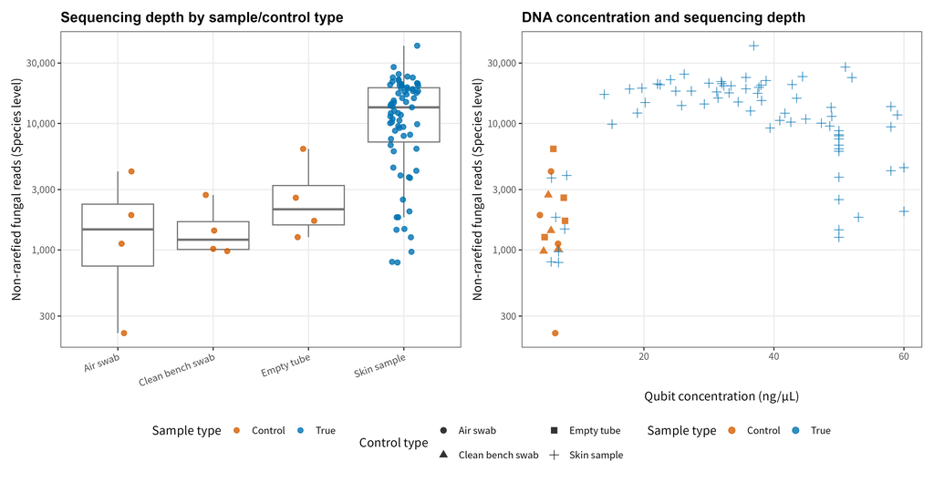

- Negative control에서도 fungal read가 확인되며 control type별 depth 차이가 존재함.
- 현재 입력은 최종 feature table 이후의 count만 포함하므로 NC read가 demultiplexing, Cutadapt, ITSxpress, denoising/merging 또는 chimera removal 중 어느 단계에서 유지되었는지는 판정할 수 없음.

## 1.5 Rarefaction trend

- Rarefaction은 sample filtering 또는 분석 포함 기준으로 사용하지 않음.
- 각 library의 full non-rarefied count에서 sequencing depth 증가에 따른 expected observed richness 추이만 확인함.

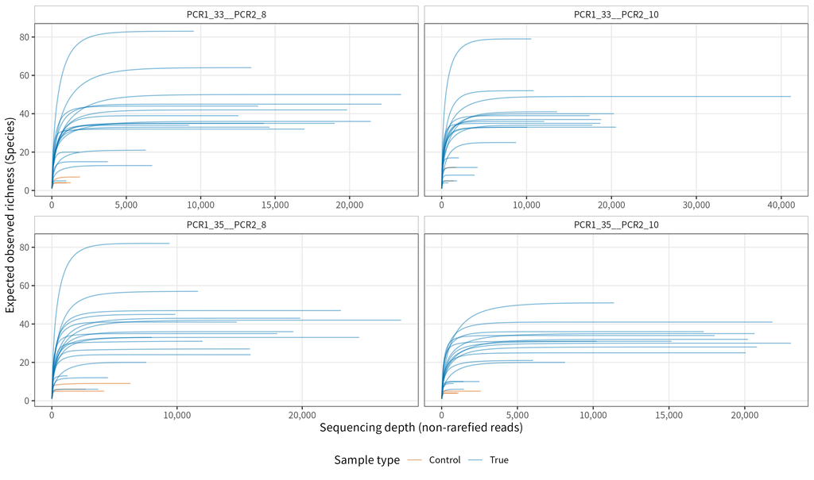

## 1.6 NC-ranked top 50 Species heatmap

| Species | NC_Mean_Relative_Abundance | NC_Prevalence | NC_Reads |
| --- | --- | --- | --- |
| Malassezia restricta | 0.405992479533977 | 1 | 12444 |
| Fungi k | 0.3107236220757107 | 1 | 4941 |
| Ascomycota p | 0.0541803073603736 | 0.9166666666666666 | 798 |
| Malassezia dermatis | 0.03260047976279653 | 0.1666666666666667 | 958 |
| Ascomycota sp | 0.03209097250655869 | 0.1666666666666667 | 437 |
| Aspergillus clavatophorus | 0.02054612937433722 | 0.08333333333333333 | 465 |
| Pleosporales sp | 0.019404393892287 | 0.1666666666666667 | 492 |
| Trametes hirsuta | 0.01843950864444016 | 0.1666666666666667 | 508 |
| Malassezia sp | 0.01770268765808172 | 0.1666666666666667 | 755 |
| Aureobasidium tremulum | 0.01729346932120636 | 0.5833333333333334 | 158 |

[output cut: 40 more lines]

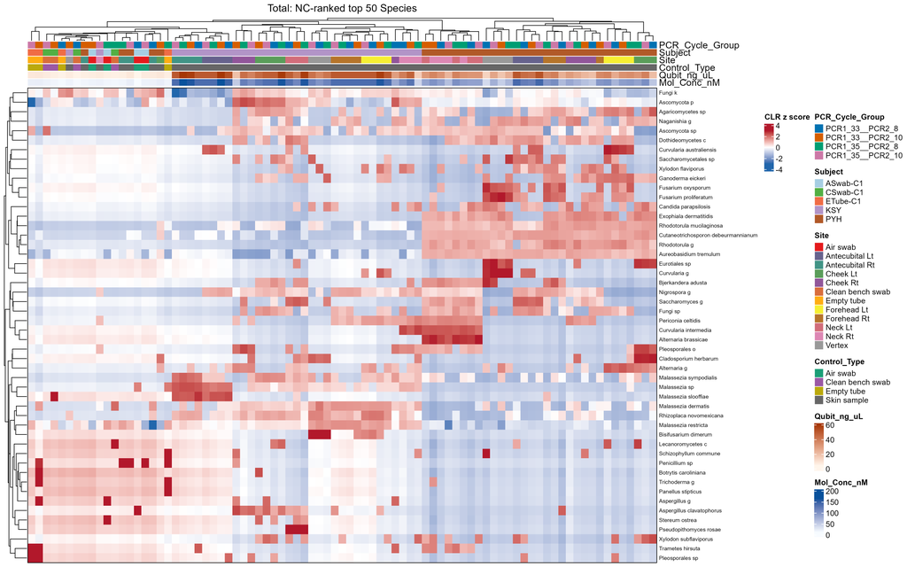

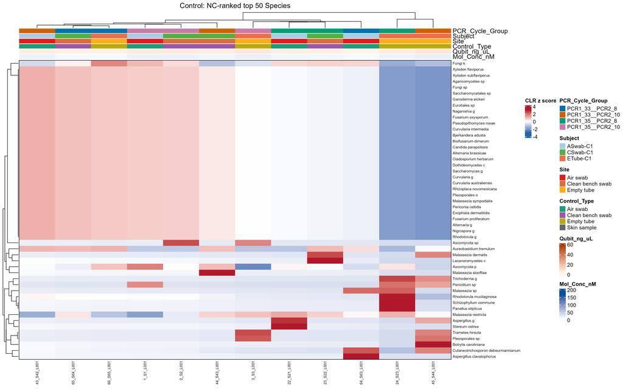

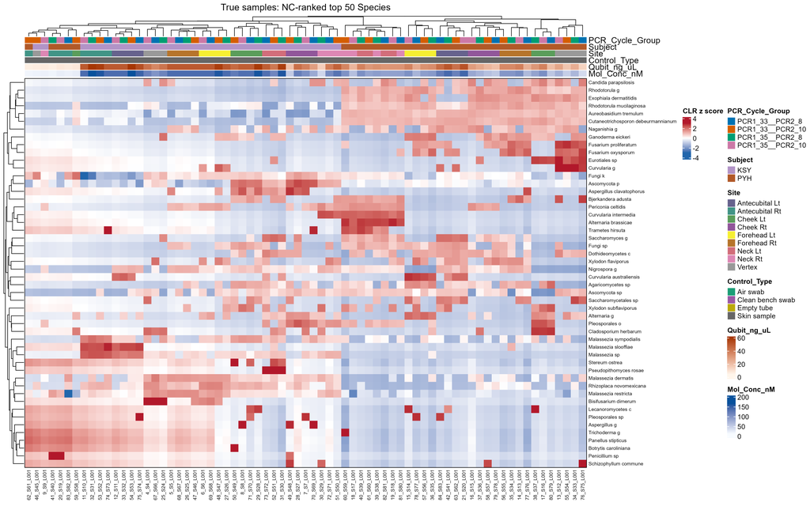

# 2 2. Alpha diversity

- 지수: Observed species, Shannon, Simpson
- 비교군: True vs Control
- 검정: 독립표본 Wilcoxon rank-sum test, paired structure 미적용
- multiple testing: 세 alpha index의 True vs Control 검정에 BH correction 적용
- 입력: non-rarefied phyloseq count의 전체 83개 library

| Metric | N_Control | N_True | Median_Control | Median_True | P_value | P_adjust_BH | Significant |
| --- | --- | --- | --- | --- | --- | --- | --- |
| Observed species | 12 | 71 | 5 | 33 | 3.912845812671637e-07 | 1.173853743801491e-06 | *** |
| Shannon | 12 | 71 | 1.075894706968766 | 1.479012102217373 | 0.004856897487622503 | 0.007285346231433754 | ** |
| Simpson | 12 | 71 | 0.5613097271256744 | 0.592841218119901 | 0.810676249773879 | 0.810676249773879 | ns |

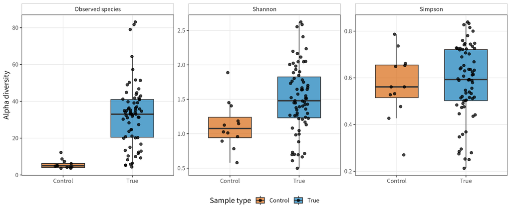

## 2.1 Skin sample별 alpha diversity

- Skin은 group mean으로 합치지 않고 각 library를 하나의 점과 표의 한 행으로 제시함.
- x축 site는 좌/우 방향을 포함하며, panel은 대상자별로 분리하고 색은 PCR 조건을 나타냄.
- 동일 `Subject × Skin site`에서 PCR 조건이 반복된 구조이므로 이 그림은 sample-level pattern 확인용임.

| SampleID | Subject | Region | Direction | Skin_Site | PCR_Cycle_Group | Metric | Value |
| --- | --- | --- | --- | --- | --- | --- | --- |
| 75_S74_L001 | KSY | Antecubital | Lt | Antecubital Lt | PCR1_33__PCR2_8 | Observed species | 20 |
| 75_S74_L001 | KSY | Antecubital | Lt | Antecubital Lt | PCR1_33__PCR2_8 | Shannon | 1.730942321107996 |
| 75_S74_L001 | KSY | Antecubital | Lt | Antecubital Lt | PCR1_33__PCR2_8 | Simpson | 0.7260251009364554 |
| 54_S53_L001 | KSY | Antecubital | Lt | Antecubital Lt | PCR1_33__PCR2_10 | Observed species | 17 |
| 54_S53_L001 | KSY | Antecubital | Lt | Antecubital Lt | PCR1_33__PCR2_10 | Shannon | 1.671104538426425 |
| 54_S53_L001 | KSY | Antecubital | Lt | Antecubital Lt | PCR1_33__PCR2_10 | Simpson | 0.7258240503563046 |
| 33_S32_L001 | KSY | Antecubital | Lt | Antecubital Lt | PCR1_35__PCR2_8 | Observed species | 13 |
| 33_S32_L001 | KSY | Antecubital | Lt | Antecubital Lt | PCR1_35__PCR2_8 | Shannon | 1.700991033002538 |
| 33_S32_L001 | KSY | Antecubital | Lt | Antecubital Lt | PCR1_35__PCR2_8 | Simpson | 0.7479743937376071 |
| 12_S11_L001 | KSY | Antecubital | Lt | Antecubital Lt | PCR1_35__PCR2_10 | Observed species | 10 |

[output cut: 203 more lines]

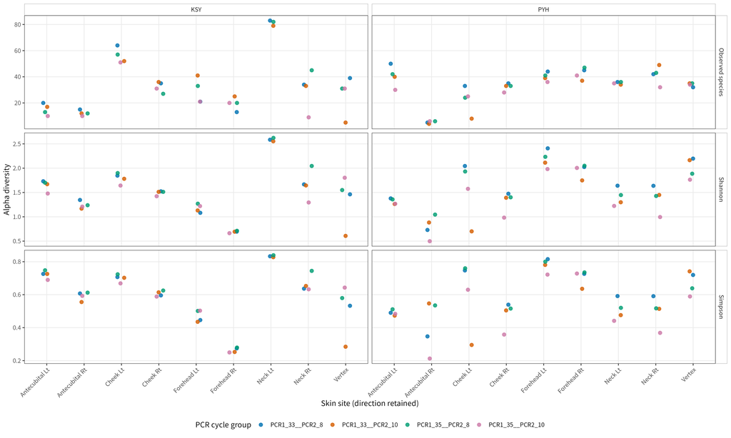

- True–Control 차이는 library 단위의 탐색 결과이며 동일 source/subject의 PCR 조건 반복을 독립 표본으로 간주한 제한이 있음.
- 독립적인 biological replicate가 적으므로 adjusted p-value만으로 생물학적 차이를 확정하지 않음.

# 3 3. Beta diversity

- distance: non-rarefied count에서 Bray–Curtis relative abundance 및 Jaccard presence/absence를 계산함
- ordination: PCoA
- marginal plot: PCoA1 및 PCoA2의 Sample type별 density를 함께 제시함
- PERMANOVA: `Sample_Type` 단일 predictor, 999 permutations, seed 42
- dispersion: `betadisper` 후 999-permutation test
- 반복측정: `Sample_Type`이 subject/source 내부에서 변하지 않아 strata 적용 시 group 효과를 검정할 수 없음. 따라서 unstratified 결과를 탐색값으로만 제시함
- multiple testing: 두 distance의 PERMANOVA와 dispersion p-value에 각각 BH correction 적용

| Distance | N | PERMANOVA_R2 | PERMANOVA_P | Betadisper_P | PERMANOVA_P_adjust_BH | Betadisper_P_adjust_BH |
| --- | --- | --- | --- | --- | --- | --- |
| Bray–Curtis | 83 | 0.07316520224178222 | 0.001 | 0.001 | 0.001 | 0.001 |
| Jaccard | 83 | 0.09712039677196495 | 0.001 | 0.001 | 0.001 | 0.001 |

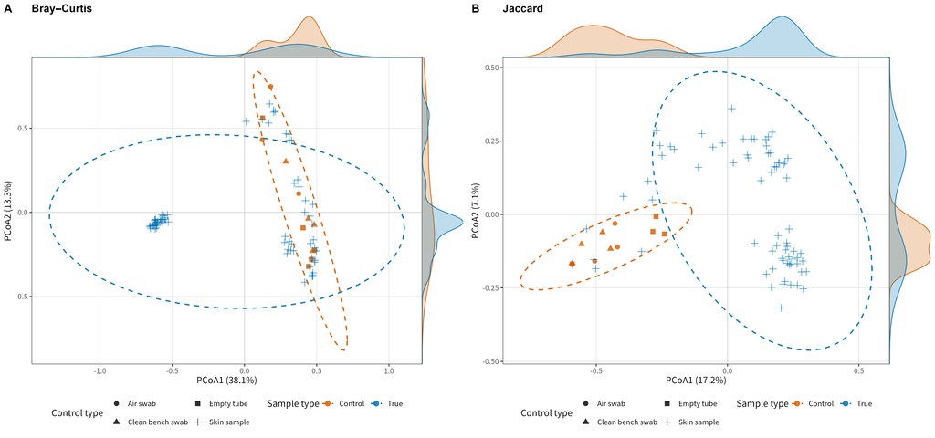

## 3.1 Skin sample별 beta diversity

- Skin library만 분리하여 대상자와 좌/우 포함 site를 동시에 표시함.
- 탐색적 PERMANOVA는 `Subject + Skin_Site + PCR_Cycle_Group`를 함께 넣어 각 요인의 주변효과를 계산함.
- 동일 biological unit에서 PCR 조건이 반복되므로 permutation p-value는 확증 검정이 아니라 구조 확인용임.

| Distance | Term | Df | R2 | F | P_value | P_adjust_BH |
| --- | --- | --- | --- | --- | --- | --- |
| Bray–Curtis | Subject | 1 | 0.4309253054573469 | 73.70207523287321 | 0.001 | 0.001 |
| Bray–Curtis | Skin_Site | 8 | 0.2175542787010015 | 4.651096609143598 | 0.001 | 0.001 |
| Bray–Curtis | PCR_Cycle_Group | 3 | 0.009355158349745847 | 0.5333442368290412 | 0.874 | 0.908 |
| Jaccard | Subject | 1 | 0.08967592180571837 | 8.551513877135784 | 0.001 | 0.001 |
| Jaccard | Skin_Site | 8 | 0.2754384138758521 | 3.283232794164348 | 0.001 | 0.001 |
| Jaccard | PCR_Cycle_Group | 3 | 0.02552557605995114 | 0.8113746830558105 | 0.908 | 0.908 |

| Distance | SampleID | Subject | Region | Direction | Skin_Site | PCR_Cycle_Group | Axis1 | Axis2 |
| --- | --- | --- | --- | --- | --- | --- | --- | --- |
| Bray–Curtis | 75_S74_L001 | KSY | Antecubital | Lt | Antecubital Lt | PCR1_33__PCR2_8 | -0.3852542891358289 | -0.2681687252356743 |
| Bray–Curtis | 54_S53_L001 | KSY | Antecubital | Lt | Antecubital Lt | PCR1_33__PCR2_10 | -0.4041059623906052 | -0.2643084226960157 |
| Bray–Curtis | 33_S32_L001 | KSY | Antecubital | Lt | Antecubital Lt | PCR1_35__PCR2_8 | -0.3558793977044669 | -0.2830975758542643 |
| Bray–Curtis | 12_S11_L001 | KSY | Antecubital | Lt | Antecubital Lt | PCR1_35__PCR2_10 | -0.3658494413492018 | -0.2701384095131092 |
| Bray–Curtis | 74_S73_L001 | KSY | Antecubital | Rt | Antecubital Rt | PCR1_33__PCR2_8 | -0.3815210378490185 | -0.2387232825917631 |
| Bray–Curtis | 53_S52_L001 | KSY | Antecubital | Rt | Antecubital Rt | PCR1_33__PCR2_10 | -0.3537430743988607 | -0.2096396688179922 |
| Bray–Curtis | 32_S31_L001 | KSY | Antecubital | Rt | Antecubital Rt | PCR1_35__PCR2_8 | -0.3941613953527143 | -0.2489289166547628 |
| Bray–Curtis | 11_S10_L001 | KSY | Antecubital | Rt | Antecubital Rt | PCR1_35__PCR2_10 | -0.3473400258363702 | -0.2495017233760917 |
| Bray–Curtis | 71_S70_L001 | KSY | Cheek | Lt | Cheek Lt | PCR1_33__PCR2_8 | -0.38482617603433 | 0.4810115587966321 |
| Bray–Curtis | 50_S49_L001 | KSY | Cheek | Lt | Cheek Lt | PCR1_33__PCR2_10 | -0.3989529690451976 | 0.4764345651705397 |

[output cut: 132 more lines]

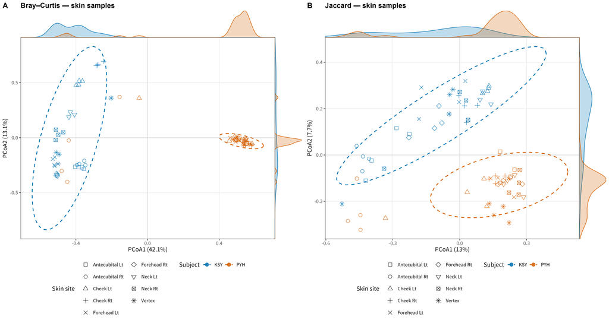

- PERMANOVA와 betadisper를 함께 확인해야 centroid 차이와 dispersion 차이를 구분할 수 있음.
- group과 subject/source가 완전히 분리되어 있어 현재 p-value는 biological replicate 수준의 확증 통계로 해석할 수 없음.

# 4 4. Taxonomic composition

- taxonomic level: Species
- 표시 기준: 전체 sample mean relative abundance 상위 14 taxa
- 분석 단위: non-rarefied species count의 sample별 relative abundance
- taxa 차이: 상위 14 taxa의 True vs Control library-level Wilcoxon test 및 BH correction

| Display_Taxon | Mean_Control | Mean_True | Prevalence_Control | Prevalence_True | P_value | P_adjust_BH | Significant |
| --- | --- | --- | --- | --- | --- | --- | --- |
| Nigrospora g | 0 | 0.01735797772246859 | 0 | 0.676056338028169 | 0.0001085505354246496 | 0.001131197384071938 | ** |
| Rhizoplaca novomexicana | 0 | 0.0073677749513681 | 0 | 0.6338028169014085 | 0.0002423994394439867 | 0.001131197384071938 | ** |
| Rhodotorula mucilaginosa | 7.94533608771651e-05 | 0.02081861873447221 | 0.08333333333333333 | 0.6901408450704225 | 0.0001663823780218635 | 0.001131197384071938 | ** |
| Fungi k | 0.3107236220757107 | 0.1055438886196971 | 1 | 0.9859154929577465 | 0.0006148657549146418 | 0.001721624113760997 | ** |
| Malassezia sympodialis | 0 | 0.00876487257148179 | 0 | 0.5915492957746479 | 0.0005155653799515383 | 0.001721624113760997 | ** |
| Cutaneotrichosporon debeurmannianum | 0.0003729347373572003 | 0.03701087546152337 | 0.1666666666666667 | 0.6197183098591549 | 0.002434476206938978 | 0.005680444482857615 | ** |
| Alternaria g | 0 | 0.0125960186382508 | 0 | 0.3943661971830986 | 0.01000322022972708 | 0.01750563540202238 | * |
| Aureobasidium tremulum | 0.01729346932120636 | 0.270131166183444 | 0.5833333333333334 | 0.8591549295774648 | 0.009939319344763347 | 0.01750563540202238 | * |
| Ascomycota sp | 0.03209097250655869 | 0.006922555039708923 | 0.1666666666666667 | 0.7183098591549296 | 0.01492373668486952 | 0.02321470150979702 | * |
| Pleosporales o | 0 | 0.006277500732171604 | 0 | 0.2957746478873239 | 0.03334465921166409 | 0.04668252289632972 | * |

[output cut: 4 more lines]

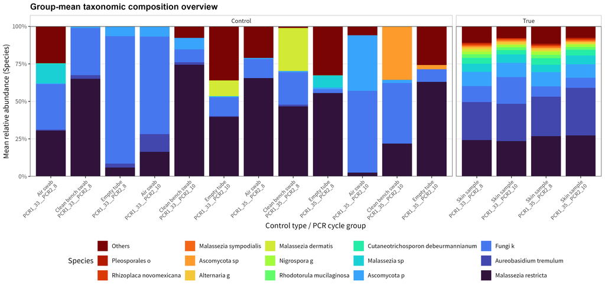

## 4.1 Skin sample별 taxonomic composition

- 아래 stacked bar의 각 막대는 개별 Skin library 한 개이며 평균으로 합치지 않음.
- 대상자와 PCR 조건을 panel로 분리하고, 좌/우 포함 site와 SampleID는 표에서 함께 확인함.

| SampleID | Subject | Region | Direction | Skin_Site | PCR_Cycle_Group | Read_Depth | Qubit_ng_uL | Mol_Conc_nM |
| --- | --- | --- | --- | --- | --- | --- | --- | --- |
| 75_S74_L001 | KSY | Antecubital | Lt | Antecubital Lt | PCR1_33__PCR2_8 | 1813 | 53 | 146 |
| 74_S73_L001 | KSY | Antecubital | Rt | Antecubital Rt | PCR1_33__PCR2_8 | 3758 | 50 | 137.7 |
| 71_S70_L001 | KSY | Cheek | Lt | Cheek Lt | PCR1_33__PCR2_8 | 13400 | 48.8 | 134.4 |
| 70_S69_L001 | KSY | Cheek | Rt | Cheek Rt | PCR1_33__PCR2_8 | 14244 | 29.3 | 80.7 |
| 69_S68_L001 | KSY | Forehead | Lt | Forehead Lt | PCR1_33__PCR2_8 | 6307 | 50 | 137.7 |
| 68_S67_L001 | KSY | Forehead | Rt | Forehead Rt | PCR1_33__PCR2_8 | 6740 | 50 | 137.7 |
| 73_S72_L001 | KSY | Neck | Lt | Neck Lt | PCR1_33__PCR2_8 | 9536 | 48.6 | 133.9 |
| 72_S71_L001 | KSY | Neck | Rt | Neck Rt | PCR1_33__PCR2_8 | 9206 | 39.4 | 108.5 |
| 67_S66_L001 | KSY | Vertex | - | Vertex | PCR1_33__PCR2_8 | 12533 | 36.4 | 100.3 |
| 54_S53_L001 | KSY | Antecubital | Lt | Antecubital Lt | PCR1_33__PCR2_10 | 2017 | 60 | 165.3 |

[output cut: 61 more lines]

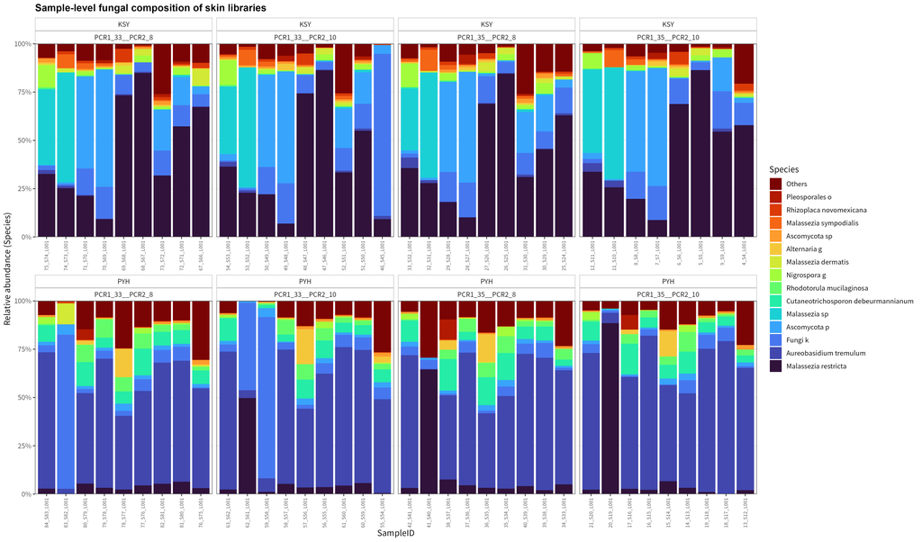

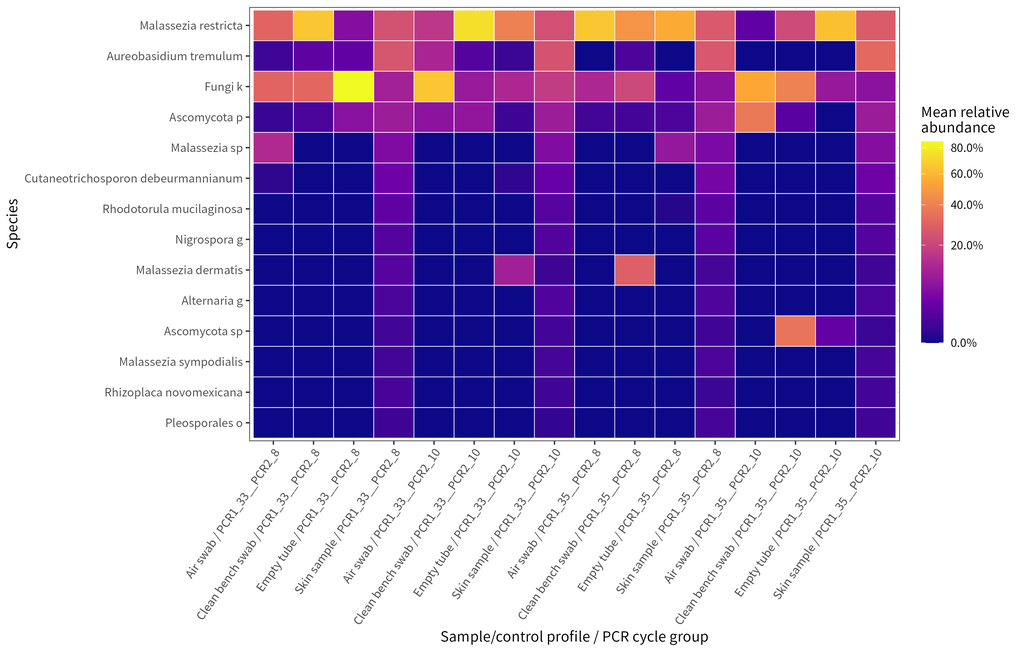

# 5 5. 결론

- 총 83개 library와 431개 species-level taxon이 phyloseq object에 포함됨.
- Rarefaction에 의한 sample filtering 없이 전체 83개 library에서 alpha/beta/taxa를 평가함.
- Skin은 71개 library를 대상자와 좌/우 포함 site별로 유지했으며, 18개 Subject × Site biological unit의 sample-level alpha, beta 및 taxa 결과를 별도 제시함.
- Alpha diversity에서 가장 작은 BH-adjusted p-value는 Observed species의 1.17e-06로 확인됨.
- Beta diversity에서 가장 작은 BH-adjusted PERMANOVA p-value는 Bray–Curtis의 0.001이며, subject/source confounding으로 확증적 해석은 제한됨.
- 상위 14 species 중 library-level True–Control 비교에서 BH-adjusted p < 0.05인 taxon은 10개로 확인됨.
- Negative control의 read와 taxonomic profile이 확인되어 후속 decontam 평가가 필요함.

# 6 6. 한계점 및 향후 분석 예정

- Skin은 2명과 좌/우 포함 9개 해부학적 site로 구성되며, Subject × Site별 결과를 개별 sample 수준으로 제시했지만 대상자 수가 2명뿐이므로 일반화가 제한됨.
- 동일 source/subject에서 PCR cycle 조건이 반복되어 library-level Wilcoxon 및 PERMANOVA의 독립성 가정이 충족되지 않음.
- 현재 metadata에 Mock sample이 없어 positive-control recovery 및 expected composition을 평가하지 못함.
- QC20/QC30, maxEE 22/44/88 및 ITSxpress 사용 여부가 metadata에 없어 preprocessing parameter별 결과를 비교하지 못함.
- 현재 count는 최종 feature table 단계의 산출물이므로 NC read가 유입 또는 유지된 정확한 pipeline stage를 특정하지 못함.
- taxonomy qza 원본이 없어 phyloseq taxonomy는 taxa barplot의 species-level aggregated count에서 재구성됨. ASV-level contaminant 판정 전 원본 feature table과 taxonomy artifact 확인이 필요함.
- Rarefaction은 observed richness trend 확인에만 사용했으며 sample filtering 또는 diversity 계산 입력으로 사용하지 않음.
- decontam method, threshold 및 contaminant removal은 적용하지 않음.

향후 분석 우선순위:

1. 각 QC/maxEE/ITSxpress 조합의 feature table, taxonomy, metadata 및 DADA2/ITSxpress 단계별 read tracking table을 동일한 sample key로 통합함.
2. batch balance와 control source 구성을 확인한 후 pooled 또는 batch-stratified decontam 여부 및 method를 결정함.
3. 승인된 decontam 설정에서 threshold sensitivity와 alpha/beta/taxa before–after 비교를 수행함.